# Predictions: Theory and Practice

Part II: Subjective judgement

Patrick Schmidt

University of Heidelberg

# Heuristics and Biases

## Introduction

- Terminology
  - Heuristics: Mental shortcuts.
  - Biases: Systematic deviations from rationality.
- Evolutionary perspective
  - human perception and decision process adapted to certain environment
  - heuristics for forming beliefs developed
  - but those heuristics can be wrong for other environments
- nature vs nurture?
  - always hard to tell
  - but also culture subject to survival of the fittest
  - biases remain relevant irrespective of origin

### Bias

- belief biases as short-hand for “errors in probabilistic reasoning.”
  - deviation in probabilities
  - or from Bayesian updating
- two possible origins
  - imperfect compliance to probability theory
  - mental model that is not accurate for reality
- identifying heuristics and biases from experiments and examples is difficult
  - many of the presented conclusions are contested or not universal
  - you should be aware that the biases might be relevant

### Goals

- learn common heuristics in belief formation
- learn about biases arising from them

### Literature

- partly based on Benjamin (2019)
- original research program by Kahnemann and Tversky
  - see Kahneman et al. (1982)
  - set of experiments that reveals common patterns in belief formation and decision making
- behavioral economics more focused on irrational decisions
  - irrational decisions follow from irrational predictions

## Biases on samples

### Partition dependence

- $P(A) < P(A \cap B) + P(A \cap B^c)$
- people assign greater total probability to an event when it is described as the union of subevents

Examples:

- What is the probability that the next person coming through the door is
  - … a lawyer?
  - … a lawyer and wears a suit?
- What is your probability of a
  1. cardiovascular disease
  2. heart attack
  3. stroke

### Sample-size neglect

- Law of large numbers: For $y_i \sim_{iid} B(p)$, it holds that
  $$\frac 1 n \sum y_i \to_p p$$
  - puts more mass around the probability, the larger the sample size
- **sample-size neglect**: sample size not sufficiently accounted for

Example:

- What is the distribution of the ratio of girls among 4 babies?
  - …among 10 babies?
  - …among 100 babies?

### Simulation: True distribution of sample average

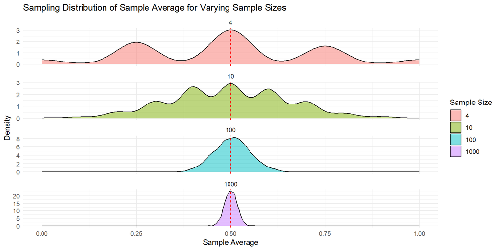

### Overconfidence

- Overestimating the accuracy of predictions
- also called overprecision
  - overconfidence used more generally for overestimating own performance (also beyond predictions)
- for real-valued targets, the prediction is too sharp
  - not measurable with point forecasts alone

### Example: 90% Confidence Interval

- Ask: give a range you are 90% sure contains the true answer
  - e.g., “In what year was the Eiffel Tower built?” → [lower, upper]
  - if you are well-calibrated, true values fall inside your range 90% of the time
- Typical result: people are right only **40–60%** of the time
  - intervals are far too narrow

### Ignoring non-randomness

- random samples are commonly the basis in statistics
- but non-random samples are everywhere
  - running a race / driving on the street
  - number of friends
  - communication on positive / negative aspects
  - number of students in class
  - time series data

## Biases on sequences

### Gambler’s fallacy

- “Observing one event reduces the likelihood of observing it again”
- wrong for independent samples
- especially wrong for independent identically distributed samples, where $p$ is unknown
  - after observing the event, you update $p$ to a higher posterior value
- Examples:
  - In gambling: “I lost the last rounds, now I am more likely to win.”
  - coin tosses: “After observing four times head, the next toss is more likely tails.”
  - “They had three boys in a row. The fourth child will probably be a girl.”

### Hot Hand Fallacy

- “A streak of successes increases the probability of the next success”
- Opposite error to the gambler’s fallacy
- Original example: basketball
  - after several consecutive made shots, the next shot “feels” more likely to go in
- Also appears in: investment returns, creative output, sports performance

### Law of Small Numbers (LSN)

- “a small sample should look representative of the population”
  - people expect even short sequences to mirror the long-run frequency
- Example: a fair coin flipped 6 times
  - sequence H-H-H-T-T-T feels *less* random than H-T-H-T-H-T, even though both are equally likely
  - sequence H-H-H-H-H-H feels *suspicious*, as if a correction is due
- **Connection to gambler’s fallacy:** LSN is the root cause
  - if you believe small samples must be representative, then after too many heads you expect the sequence to “self-correct”

## Biases in updating

- consider Bayes updating with states A and B of the world and a signal S

$$P(A|S) = \frac{P(S \& A)}{P(S)}$$

- Or in its **posterior-odds** form

$$\frac{P(A|S)}{P(B|S)} = \frac{P(S\&A)}{P(S\&B)}= \frac{P(S|A)}{P(S|B)} \cdot \frac{P(A)}{P(B)}$$

- P(S|A) is the likelihood of signal S given state A.
- P(A) is the prior probability of state A.

### Experimental setting

- a typical experiment would look like this
  - two urns named A and B with red and blue balls
  - urn A: 90% red and 10% blue
  - urn B: 10% red and 90% blue
  - unknown which type of urn this is
  - signal S = the result of some draws from the urn (balls are returned after each draw)
- What do we learn from a signal S = RRBR?
  - more red, more likely to be urn A
  - what is your probability prediction for it being urn A?
- Bayes solution
  - $p(A), p(B) = 0.5$ (if urn randomly chosen)
  - $p(S=RRBR|A) = 0.9^3 \times 0.1^1$

### Experiment Analysis

- Bayes solution can be computed for
  $$\frac{P(A|S)}{P(B|S)} = \underbrace{\frac{P(S|A)}{P(S|B)}}_{\text{likelihood ratio}} \cdot \underbrace{\frac{P(A)}{P(B)}}_{\text{prior ratio}}$$
- but hard to do in your head (participants normally don’t do it)
- How can we anlayse deviations from Bayesian updating?
  - take log of equation to linearize

  $$log(\frac{P(A|S)}{P(B|S)}) = log (\frac{P(S|A)}{P(S|B)}) + log (\frac{P(A)}{P(B)})$$
  - posterior ratio we measure
  - likelihood ratio we can compute
  - prior ratio we can experimentally control

### Empirical findings

- If we analyze the equation
  $$log(\frac{P(A|S)}{P(B|S)}) = log (\frac{P(S|A)}{P(S|B)}) + log (\frac{P(A)}{P(B)})$$
  in experiments we find:
- underinference is common (effect of likelihood ratio is smaller)
- underinference is larger if sample size is large
  - participants learn not enough from observing one signal
  - but discrepancy is even worse for multiple signals
- base rate neglect is common (effect of prior ratio is smaller)

### Anchoring

- Initial information (anchor) influences judgments
- even when the anchor is irrelevant
- Example:
  - Write the last two digits of your social security number down
  - What would you pay for getting this chocolat bar?
  - Result: Offers more than 60% higher if social security number is high

### Motivated beliefs

The standard model postulates a separation of preferences (utility function) and beliefs (probabilities)

- but empirically this separation is consistently violated
- holding a belief can provide direct utility
  - ego protection
  - identity
  - wishful thinking

### Example: Partisan inflation expectations

[figure not shown]

### Example: Scams

- online scams often start with small money amounts and escalate later
- why? Let’s think about the probability that a request is a scam.
  - unknown persons asks for money $\Rightarrow$ probably scam
  - unknown persons asks for more money after I already gave some $\Rightarrow$ even higher probability of scam, but acknowledgement would hurt.

### Confirmation Bias

- Confirmation bias is the tendency to search for, interpret, focus on and remember information in a way that confirms one’s preconceptions.
- Seeking/interpreting confirming information.
- Ignoring contradictory evidence.
- “Echo chambers”
- Affects information search and interpretation, leading to biased (and overprecise) predictions.

### Hindsight Bias

- “I knew it all along”: after learning an outcome, people believe they had predicted it all along
  - memory of prior beliefs is distorted toward the observed outcome
- Undermines learning from experience
  - if you remember predicting correctly, you don’t update your method

## Heuristics

### Availability Heuristic

- Ease of recall influences probability judgments ($\hat p$)
  - recall more available, higher prediction $\hat p$
  - e.g., vividness distorts predictions of rare but salient events such that $E[y|\hat p]<\hat p$
- Examples:
  - Plane crashes (vivid)
  - car accidents (less vivid, but more dangerous)
  - terror attacks (vivid)
  - obesity (less vivid, but more casualties)

### Example: 9/11 terrorist attacks made risk of flying more salient

“In the aftermath of the terrorist attacks on September 11 (9/11), 2001, from October 2001 to September 2002, there were approximately 1,600 more traffic fatalities in the United States than would normally be expected.” (Gaissmaier and Gigerenzer 2012)

- Idea:
  - perceived risk of flying increases
  - people fly less, some drive instead
  - driving is risky (in fact, 30 minutes taxi ride to airport more risk than a 5 hours flight)
  - indirect effect: more traffic accidents

### Representativeness Heuristic

- Judging probability based on similarity to a prototype.
  - entails Base-rate neglect.
- Example: a person who is dressed in eccentric clothes and reading a poetry book.
  - poet or accountant?
  - looks like a typical poet
  - but many more people are accountants than poets

## Biases in decisions

- Ambiguity aversion and probability weighting originate in decision theory
- connection between reported probability prediction and decisions often not investigated in literature
- human participants act as if they have these predictions

### Ambiguity Aversion

- Preference for known risks over unknown risks.
- Affects mostly decisions in high uncertainty
- Not necessarily a bias
  - can be understood as more general decision-theory
- Connection to prediction performance unclear

### Probability Weighting Function

- Distorting probabilities, especially small and large.
- Inverse S-shape.
- Small probabilities overweighted.
- Large probabilities underweighted.
- discrimination between probabilities imperfect
- really strong probability weighting:
  - differentiate only between yes, no, maybe
  - no difference between $p = 0.3$ and $p = 0.7$

### Prob weighting function

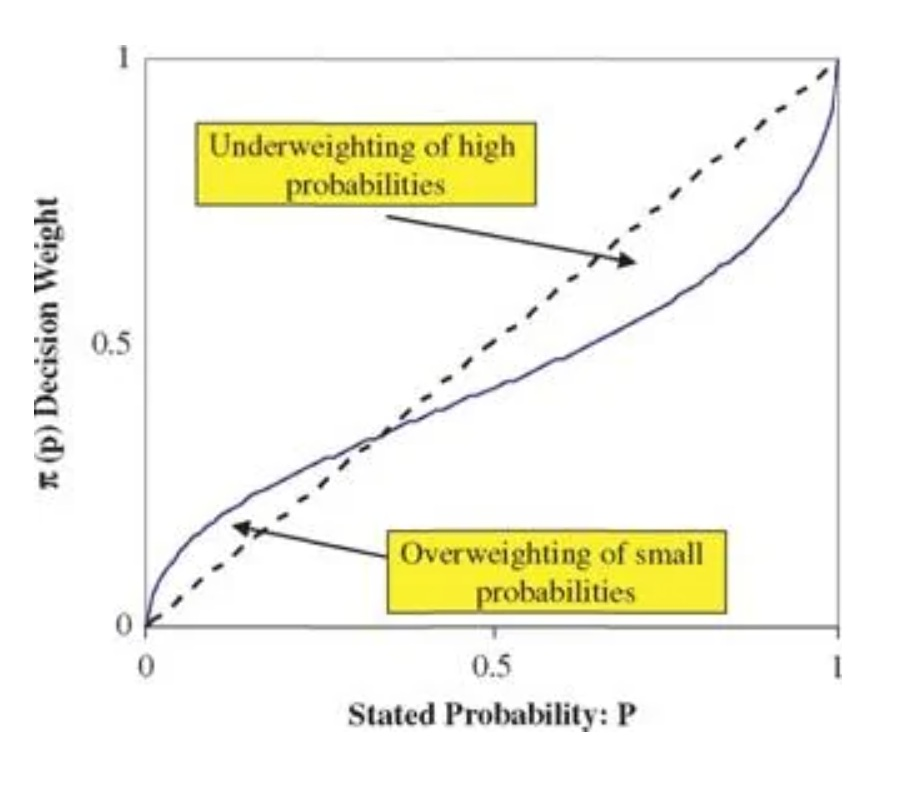

## From Problems to Solutions

- We have seen many systematic ways human judgment fails:
  - biases on samples and sequences (sample-size neglect, overconfidence, gambler’s fallacy, hot hand fallacy)
  - biases in updating (base rate neglect, anchoring, motivated beliefs, confirmation bias, hindsight bias)
  - biases in decisions (ambiguity aversion, probability weighting)
  - heuristics that distort probability judgments (availability, representativeness, conjunction fallacy)
- **Key question:** Are these failures inevitable, or can they be overcome?
- The superforecaster research program asks: what do the *best* human forecasters do differently?

# Superforecasters

## Introduction

- What characterizes good human judgement?
- based on the research program by Tetlock and coauthors (Mellers et al. 2015; Tetlock and Gardner 2016)
  - initially funded by the U.S. intelligence community.
  - “superforecasters”: ordinary people who consistently outperformed intelligence analysts with access to classified information.
- focused almost exclusively on event predictions
  - performance criterium: Quadratic score (Brier score)

### You can participate, too!

- popular options
  - good judgement open (prediction polls)
  - Metaculus (prediction poll)
  - PredictIt (Prediction market)
- no big European alternative
- our Assignment is essentially a forecasting competition
  1. define targets
  2. predict

### why human judgement?

- if there is data available, use statistical algorithms
- human judgement is used in situations, when there is no good data
- We will see with Bayesian inference: Difference vanishes to some point
  - every model can be traced back to assumptions which are ultimately based on human judgement
  - every expert can use data and algorithms to inform their judgement

## The Parable: The Hedgehog and the Fox

> “The fox knows many things, but the hedgehog knows one big thing.”
- the Hedgehog
  - **Knows “One Big Thing”:**
  - Relates everything to it
- the Fox
  - **Knows “Many Little Things”:**
  - Draws on a wide variety of experiences and information
  - Tolerant of conflicting perspectives

### Hedgehog vs. Fox: Forecasting Accuracy

- Tetlock (Tetlock and Gardner 2016):
  - **Foxes consistently outperformed hedgehogs** in making accurate forecasts
  - Hedgehogs, particularly famous ones often sought by media, tended to be *less* accurate, sometimes worse than chance.
  - Overconfidence was a key factor in hedgehog inaccuracy.

## Ingredients to super forecasting

- Superforecasters cultivate specific habits of mind and work methods
- These skills can be learned and improved
- Let’s look at the key characteristics…

### Property: Reasoning - Numerate & Probabilistic

- **Definition:** Using numbers and probabilities to express degrees of belief
- **Why it Matters:**
  - Avoids the ambiguity of vague words (“maybe,” “likely,” “possible”).
- **How to Improve:**
  - Practice translating vague feelings into specific percentages
  - Learn basic probability concepts and Bayes’ Theorem (even conceptually)
  - track your probabilistic forecasts vs. outcomes

### Example: Finding Osama bin Laden

- search for Osama bin Laden
  - early 2011 the intelligence community was growing more confident
  - eventually communicated to President Obama
  - presentations about the likelihood that Osama was indeed residing in compound in a Pakistani town
- Multiple experts with probability statement between 35% to 95%
  - with a median of 75%
- President Obama:
  - “Seems like it’s a coin flip, 50-50.”

### Property: Cautious Humility

*“Beliefs are hypotheses to be tested, not treasures to be protected.”*

- **Definition:** Acknowledging uncertainty, the limits of one’s own knowledge, and the role of chance. Understanding the world is complex and often unpredictable.
- **Why it Matters:**
  - more receptive to new evidence and correction
  - reduces overconfidence (overprecision) bias

### Property: Thinking Style - Actively Open-Minded & Curious

- **Definition:** *Actively* seeking out perspectives and evidence that challenge one’s own beliefs.
- **Why it Matters:**
  - Counteracts confirmation bias and groupthink
  - Leads to more comprehensive synthesis of information
- **How to Improve:**
  - Deliberately seek out sources and arguments that contradict your viewpoint
  - try to understand their reasoning
  - steel-man argument: presenting counter argument in its strongest form
  - don’t straw man: missrepresenting opponent’s argument

### Property: Updating - Reflective & Frequent

- **Definition:** Treating predictions not as final pronouncements but as dynamic states reflecting current knowledge.
- **Why it Matters:**
  - allows for improvement
  - theoretical consistent (Bayes rule)

### Property: Mindset - Growth Mindset

- **Definition:** Believing that prediction skill that can be developed through practice (Growth Mindset).
- **Why it Matters:**
  - Motivates continuous learning and effort.
  - Prevents discouragement from bad results

### Add-on: Teams are superior

- teams of forecasters outperformed single forecasters
- discussion and social ties improved time investement and effectiveness

### Quantitative estimates

- concepts are strongly interconnected
- difficult to measure the exact contribution of each property
- next slide shows result from (Mellers et al. 2015)
  - participants predicted political events
  - SEM (structural equation modeling)
  - structure of observed and unobserved variables
  - $A \rightarrow B$: A influences B
  - $A \leftrightarrow B$: A and B correlated
  - Directions chosen by researchers
  - AOMT: actively open-minded thinking.

### Structural equation result

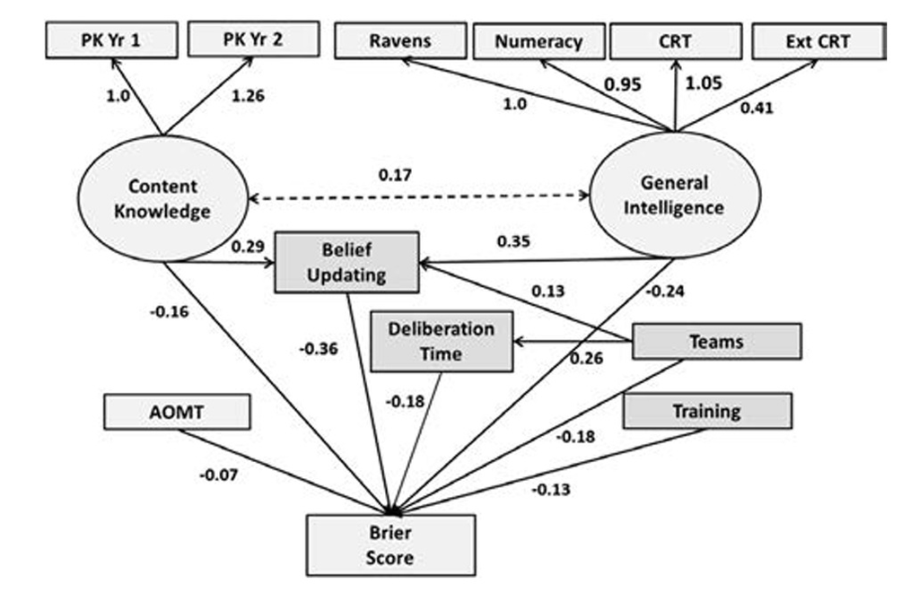

## Black swans

- The **superforecaster** agenda argues
  - find precise prediction targets
  - follow good prediction habits
  - you can achieve **quantification of uncertainty**
- Now to **“black swans”**(Taleb 2007):
  - rare
  - real
  - relavant, but ignored (!)
- black swans are everywhere and unavoidable (Taleb 2007)
  - uncertainty quantification of superforecasters an illusion (Taleb et al. 2023)

### Predictable or not?

- Clearly defined events are probabilistically predictable, but …
  - real world decision making often does not depend on single event
  - calibration/performance becomes essentially unknowable for extremly unlikely events
  - adaptation to risk generates new risk (e.g., the financial system)
  - definition of appropriate events imperfect
  - world too unstable (technological progress, climate change)

### Illustration: Extremely unlikely events

- Consider a prediction $\hat p = 0.001$
- we conjecture that the actual probability is $p = 0$
  - uncalibrated prediction
- we need to observe a lot of false event realizations to infer that kind of misscalibration

### Illustration: Intractability of real-valued prediction targets

- for risk management we are often most interested in extreme events
  - heavy rain fall
  - strong dectonic movements for earthquakes
  - large losses of financial institutions
- if we do statistical inference based on iid samples
  - most observations are not in the tail
  - inference heavily relies on shape assumptions of the distribution
- if implications/utility/loss scales strongly with magnitude, expected loss (or its variance) cannot be inferred from a sample of data

## Conclusion

- there are measures to improve predictability and appropriate reflection of uncertainty
  - probabilistic thinking
  - intellectual humility
  - active open-mindedness
  - frequent and deliberate updating
  - growth mindset
  - team work
- risk and uncertainty nowhere near to being defeated
  - in fact, may be impossible

# References

Benjamin, Daniel J. 2019. “Errors in Probabilistic Reasoning and Judgment Biases.” *Handbook of Behavioral Economics: Applications and Foundations 1* 2: 69–186.

Gaissmaier, Wolfgang, and Gerd Gigerenzer. 2012. “9/11, Act II: A Fine-Grained Analysis of Regional Variations in Traffic Fatalities in the Aftermath of the Terrorist Attacks.” *Psychological Science* 23 (12): 1449–54.

Kahneman, Daniel, Paul Slovic, and Amos Tversky. 1982. *Judgment Under Uncertainty: Heuristics and Biases*. Cambridge university press.

Mellers, Barbara, Eric Stone, Pavel Atanasov, et al. 2015. “The Psychology of Intelligence Analysis: Drivers of Prediction Accuracy in World Politics.” *Journal of Experimental Psychology: Applied* 21 (1): 1.

Taleb, Nassim Nicholas. 2007. “Black Swans and the Domains of Statistics.” *The American Statistician* 61 (3): 198–200.

Taleb, Nassim Nicholas, Ronald Richman, Marcos Carreira, and James Sharpe. 2023. “The Probability Conflation: A Reply to Tetlock Et Al.” *International Journal of Forecasting* 39 (2): 1026–29.

Tetlock, Philip E, and Dan Gardner. 2016. *Superforecasting: The Art and Science of Prediction*. Random House.

Tversky, Amos, and Daniel Kahneman. 1974. “Judgment Under Uncertainty: Heuristics and Biases: Biases in Judgments Reveal Some Heuristics of Thinking Under Uncertainty.” *Science* 185 (4157): 1124–31.